# Project 2

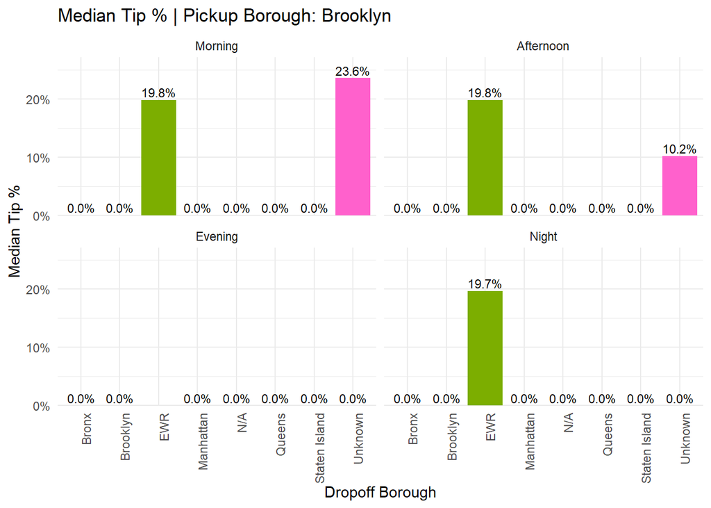

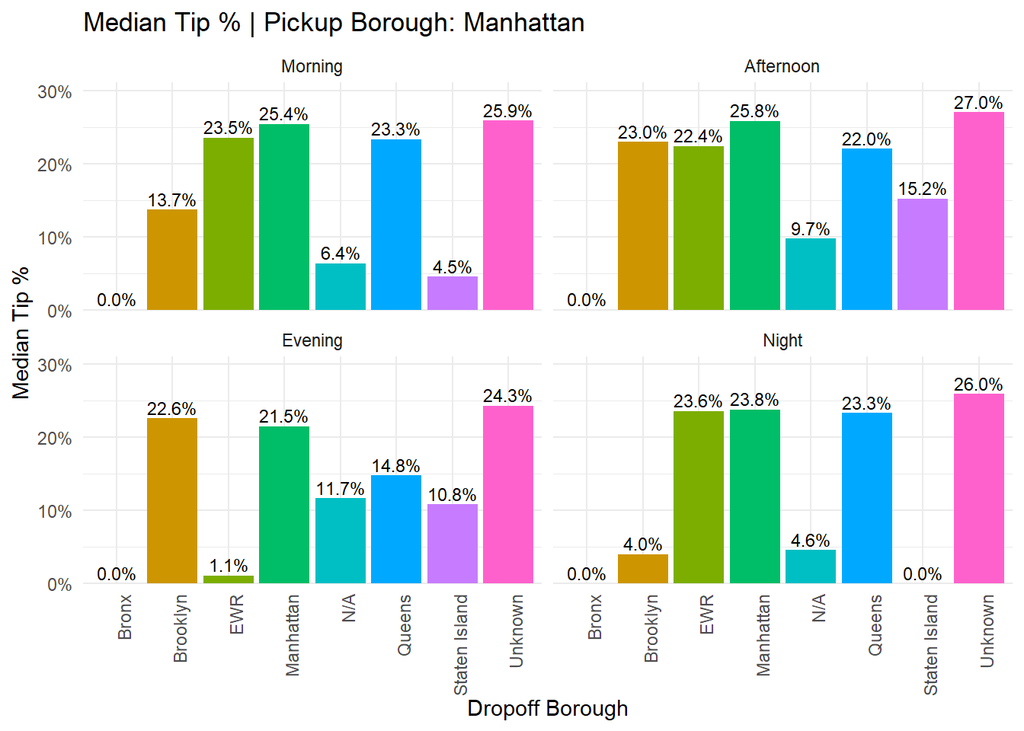

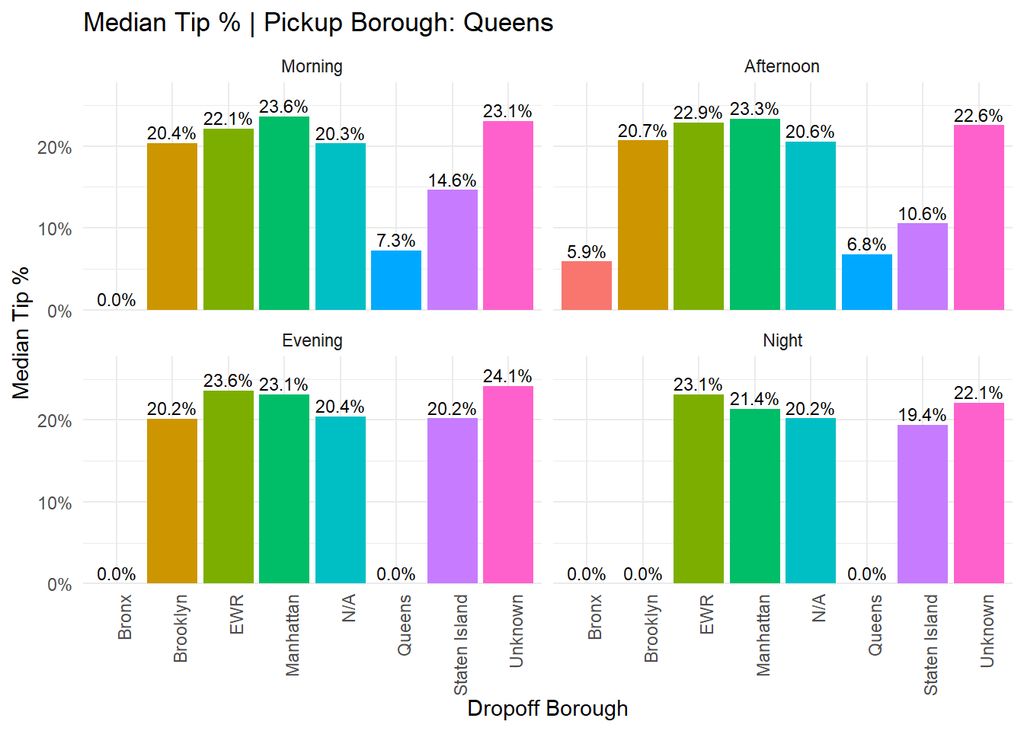

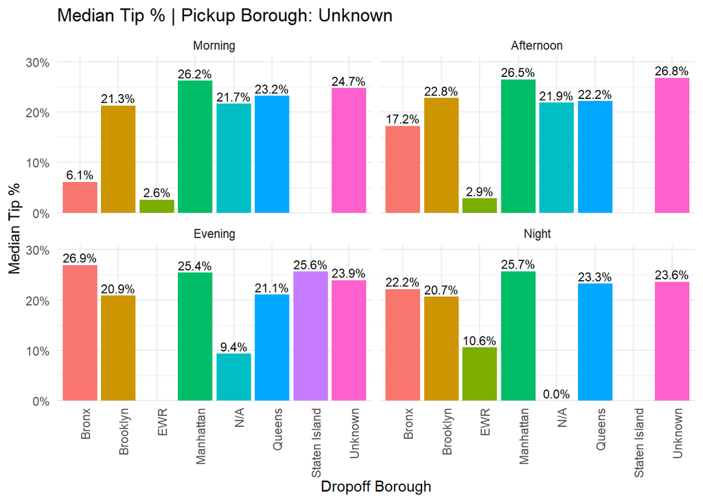

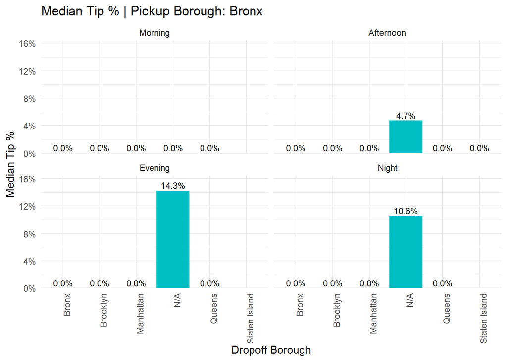

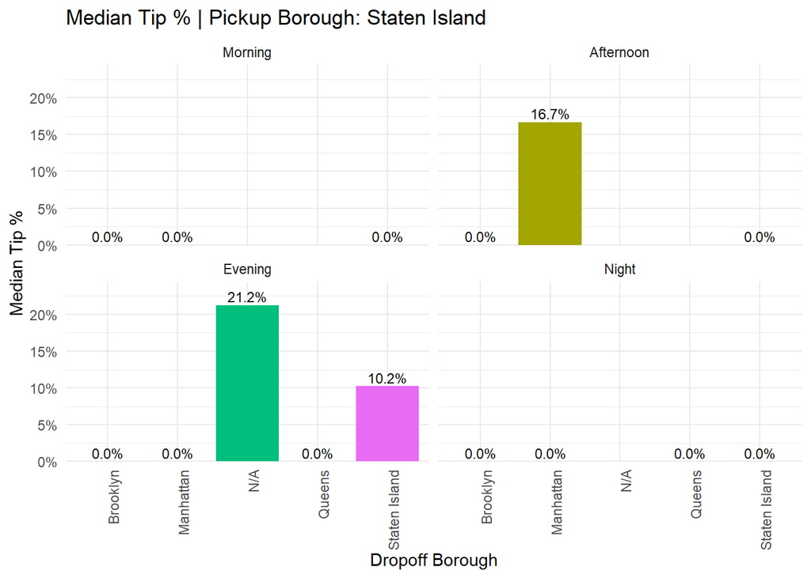

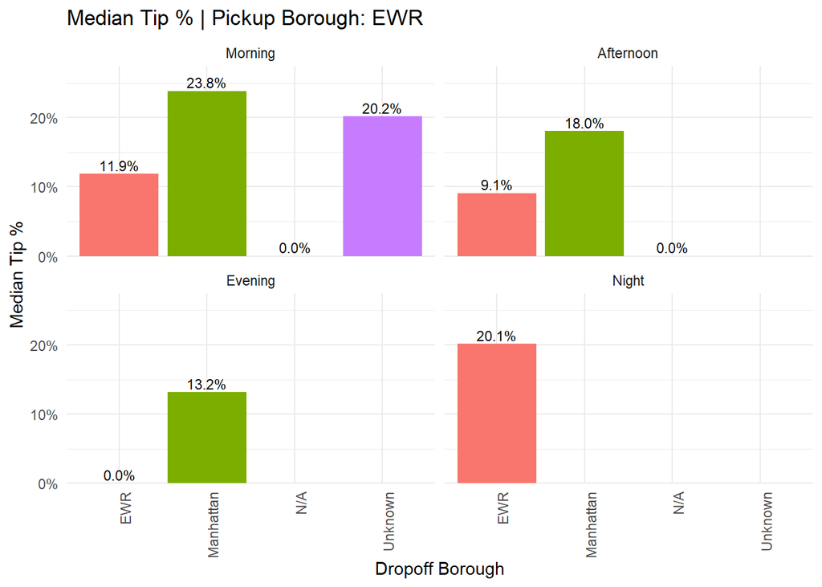

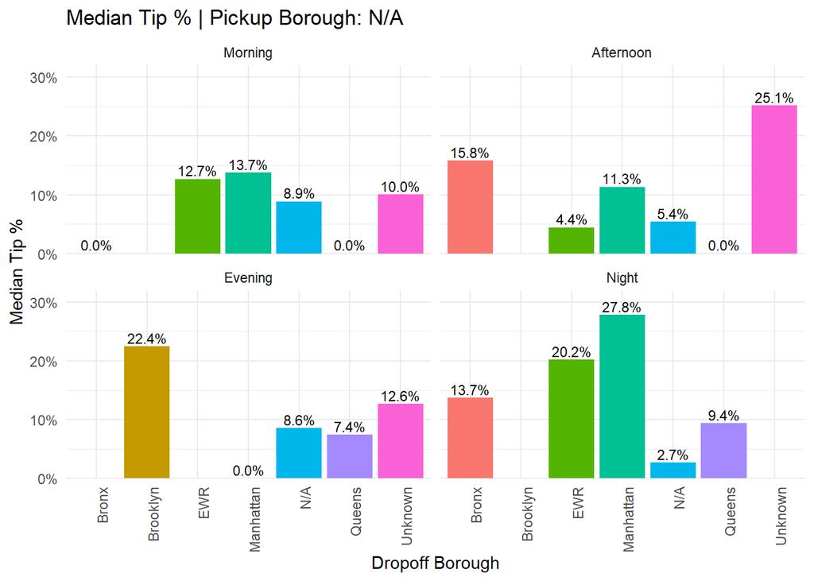

```r
for (borough in unique(taxi$pickup_borough)) {
  plot_data <- taxi %>%
    filter(pickup_borough == borough) %>%
    group_by(dropoff_borough, pickup_time_of_day) %>%
    summarise(
      median_tip = median(tip_percent_fare_amount, na.rm = TRUE),
      .groups = "drop"
    )

  plot_obj <- ggplot(
    plot_data,
    aes(x = dropoff_borough, y = median_tip, fill = dropoff_borough)
  ) +
    geom_col() +
    geom_text(
      aes(label = scales::percent(median_tip, accuracy = 0.1)),
      vjust = -0.3,
      size = 3
    ) +
    scale_y_continuous(
      labels = scales::percent_format(),
      expand = expansion(mult = c(0, 0.15))
    ) +
    facet_wrap(~ pickup_time_of_day) +
    labs(
      title = paste("Median Tip % | Pickup Borough:", borough),
      x = "Dropoff Borough",
      y = "Median Tip %"
    ) +
    theme_minimal() +
    theme(
      axis.text.x = element_text(angle = 90, hjust = 1),
      legend.position = "none"
    )

  print(plot_obj)
}
```

# Section: Tipping Behavior by Weekday

## Question: How does median tip percentage vary across different days of the week?

## Answer: Median tip percentages are relatively consistent throughout the week, generally ranging between 22% and 25%. Weekdays (Monday–Thursday) show slightly higher tipping levels (around 24%–24.6%), with Tuesday being the highest (24.6%). Tipping gradually declines toward the weekend, with Friday (23.2%), Saturday (22.2%), and Sunday (22.3%) showing slightly lower values. Overall, tipping behavior is stable across days, with only a modest decrease on weekends.

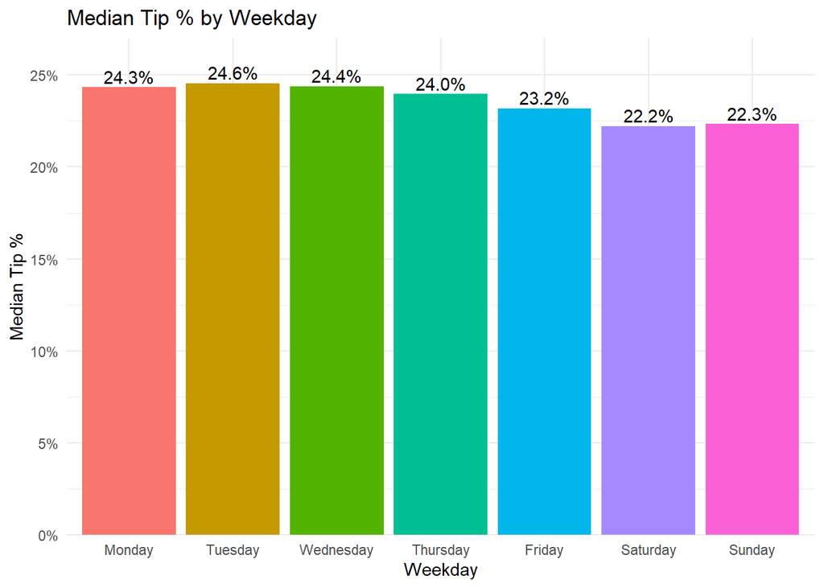

```r
taxi %>%
  filter(trip_duration_mins > 0) %>%
  group_by(weekday) %>%
  summarise(
    median_tip = median(tip_percent_fare_amount, na.rm = TRUE),
    .groups = "drop"
  ) %>%
  ggplot(aes(x = weekday, y = median_tip, fill = weekday)) +
  geom_col() +
  geom_text(aes(label = scales::percent(median_tip, accuracy = 0.1)), vjust = -0.3) +
  scale_y_continuous(labels = scales::percent_format(),
                     expand = expansion(mult = c(0, 0.1))) +
  labs(
    title = "Median Tip % by Weekday",
    x = "Weekday",
    y = "Median Tip %"
  ) +
  theme_minimal() +
  theme(legend.position = "none")
```

# Section: Tipping Behavior by Month

## Question: How does median tip percentage vary across different months of the year?

## Answer: Median tip percentages remain relatively stable throughout the year, generally ranging between 21% and 25%. Tipping is slightly higher in the early months, with January (25.4%) and April (24.8%) among the highest. Mid-year months (May–September) show a small dip, mostly around 23%, before slightly increasing again in October (24.0%) and November (24.1%). December (21.4%) has the lowest median tip percentage. Overall, tipping behavior shows minor seasonal variation but remains fairly consistent across months.

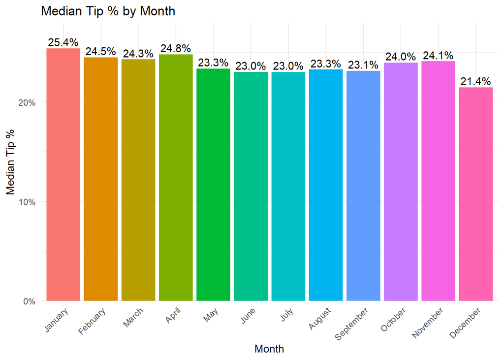

```r
taxi %>%
  group_by(month) %>%
  summarise(
    median_tip = median(tip_percent_fare_amount, na.rm = TRUE),
    .groups = "drop"
  ) %>%
  ggplot(aes(x = month, y = median_tip, fill = factor(month))) +
  geom_col() +
  geom_text(aes(label = scales::percent(median_tip, accuracy = 0.1)), vjust = -0.3) +
  scale_y_continuous(labels = scales::percent_format(),
                     expand = expansion(mult = c(0, 0.1))) +
  labs(
    title = "Median Tip % by Month",
    x = "Month",
    y = "Median Tip %"
  ) +
  theme_minimal() +
  theme(axis.text.x = element_text(angle = 45, hjust = 1),
        legend.position = "none")
```